# HWMK 1 Part 1 Auto - Homer Kay

Import Packages Below

```python
#Add packages
%matplotlib inline
import numpy as np
import matplotlib.pyplot as plt
import pandas as pd
#From Scikit Learn
from sklearn import preprocessing
from sklearn.model_selection  import train_test_split, cross_val_score, KFold
from sklearn.model_selection import GridSearchCV
from sklearn.metrics import accuracy_score, precision_score, recall_score, f1_score
from sklearn.metrics import roc_curve, auc, confusion_matrix, classification_report
#Notice I did not load my Datamining packages yet (ie decision tree). I will do that as I use them.
```

```python
# Checking Current Directory
%pwd
```

```
'/Users/homerkay'
```

```python
# Change Directory
%cd /Users/homerkay/Desktop/Pred_Models_git-master/Week 1
```

```
/Users/homerkay/Desktop/Pred_Models_git-master/Week 1
```

## Part 1

Reading in the dataset. Removed "NA" from original dataset to read in. Alternatively could have used encoding to read in. Displayed first 10 rows of dataset.

```python
## Pt 1
auto=pd.read_csv("data/AUTO2.csv", sep=",")
## Use Enconding argument, Latin-1, iso... etc to read in files properly
#Had to remove "NA" from dataset native file to get to read properly
auto.head(10)
```

|  | Name | DriveType | Mileage | FuelType | Capacity | Length | WheelBase | Width | TurningCircle | Weight | DoorTop | Luggage | FrontShoulder | FrontLegRoom | FrontHeadRoom | RearShoulder | RearLegRoom | RearHeadRoom |
| --- | --- | --- | --- | --- | --- | --- | --- | --- | --- | --- | --- | --- | --- | --- | --- | --- | --- | --- |
| 0 | Acura Integra | Front | 31 | Regular | 13.2 | 172 | 101 | 67 | 39 | 2635 | 47.5 | 13.0 | 51.5 | 41.5 | 2.0 | 46.5 | 25.0 | 0.5 |
| 1 | Acura TL | Front | 22 | Premium | 17.1 | 193 | 108 | 70 | 40 | 3460 | 50.0 | 14.0 | 56.0 | 40.5 | 2.5 | 55.0 | 27.0 | 2.0 |
| 2 | Buick Century | Front | 22 | Regular | 17.5 | 195 | 109 | 73 | 40 | 3350 | 50.5 | 17.0 | 58.0 | 44.0 | 5.0 | 57.0 | 30.0 | 2.0 |
| 3 | Buick LeSabre | Front | 20 | Regular | 17.5 | 200 | 112 | 74 | 42 | 3640 | 51.0 | 18.0 | 59.5 | 40.5 | 5.0 | 58.0 | 27.5 | 4.5 |
| 4 | Buick Park Avenue | Front | 21 | Regular | 18.5 | 207 | 114 | 75 | 43 | 3880 | 51.0 | 19.0 | 59.5 | 42.5 | 6.0 | 58.5 | 31.5 | 3.0 |
| 5 | Buick Regal | Front | 21 | Regular | 17.5 | 196 | 109 | 73 | 40 | 3325 | 50.5 | 17.0 | 58.0 | 43.0 | 5.0 | 56.5 | 29.0 | 2.5 |
| 6 | Chevrolet Cavalier | Front | 26 | Regular | 15.2 | 181 | 104 | 68 | 38 | 2795 | 50.5 | 14.0 | 54.5 | 41.5 | 4.5 | 53.5 | 28.0 | 2.0 |
| 7 | Chevrolet Impala | Front | 20 | Regular | 17.0 | 200 | 111 | 73 | 40 | 3495 | 51.5 | 18.0 | 58.5 | 42.0 | 5.0 | 58.5 | 29.0 | 2.5 |
| 8 | Chevrolet Lumina | Front | 22 | Regular | 16.6 | 201 | 108 | 73 | 44 | 3350 | 51.0 | 16.0 | 58.5 | 42.5 | 4.5 | 57.0 | 30.0 | 2.0 |
| 9 | Chevrolet Malibu | Front | 24 | Regular | 15.2 | 190 | 107 | 69 | 40 | 3075 | 50.5 | 17.0 | 55.0 | 43.0 | 4.5 | 54.0 | 30.5 | 2.0 |

Part 1 Looking at the data types column names and shapes.

```python
auto.columns
auto.shape
print(auto.dtypes)
#Changed headers to be able to code in columns
auto.Luggage.median()
```

```
Name              object
DriveType         object
Mileage            int64
FuelType          object
Capacity         float64
Length             int64
WheelBase          int64
Width              int64
TurningCircle      int64
Weight             int64
DoorTop          float64
Luggage          float64
FrontShoulder    float64
FrontLegRoom     float64
FrontHeadRoom    float64
RearShoulder     float64
RearLegRoom      float64
RearHeadRoom     float64
dtype: object
```

```
16.0
```

## Part 2

Replacing NaN with median value for missing Luggage Values.

```python
## Pt 2
#Replacing NaN with median value for missing Luggage Values
auto.Luggage.fillna(auto.Luggage.median(), inplace = True)
```

## Part 3

Viewing the means, std dev, and categorical distributions.

```python
## Pt 3
#Means, StdDev
print(auto.mean())
print() #extra prints add spaces to see info splits easily
print(auto.std())
# Distribution drive type and fuel type
print()
print(auto.groupby('DriveType').size())
print()
print(auto.groupby('FuelType').size())
```

```
Mileage            21.292453
Capacity           17.883019
Length            187.594340
WheelBase         107.632075
Width              70.915094
TurningCircle      39.849057
Weight           3502.311321
DoorTop            53.891509
Luggage            25.056604
FrontShoulder      56.471698
FrontLegRoom       41.254717
FrontHeadRoom       4.287736
RearShoulder       54.745283
RearLegRoom        28.363208
RearHeadRoom        3.023585
dtype: float64

Mileage            3.769469
Capacity           3.425714
Length            12.493639
WheelBase          7.014713
Width              3.237041
TurningCircle      2.797252
Weight           633.453939
DoorTop            5.747465
Luggage           18.235538
FrontShoulder      3.041640
FrontLegRoom       1.021775
FrontHeadRoom      1.279784
RearShoulder       7.110437
RearLegRoom        2.196895
RearHeadRoom       1.370405
dtype: float64

DriveType
Front    81
Rear     25
dtype: int64

FuelType
Premium     19
Regular     86
Regular      1
dtype: int64
```

## Part 4

Standardizing Weight Values.  
Output shows both original weight and standardized side by side.

```python
## Pt 4
#Transform to Z-Scores
#Removed Comma Separation in Weight Variable to make int
Weight_Z=pd.DataFrame((auto.Weight-auto.Weight.mean())/auto.Weight.std())
Weight=pd.DataFrame(auto.Weight)
Weight_Result = pd.concat([Weight_Z,Weight], axis=1, sort=False)
Weight_Result.columns = ['Std Weight','Weight']
Weight_Result.head(10)
```

|  | Std Weight | Weight |
| --- | --- | --- |
| 0 | -1.369178 | 2635 |
| 1 | -0.066795 | 3460 |
| 2 | -0.240446 | 3350 |
| 3 | 0.217362 | 3640 |
| 4 | 0.596237 | 3880 |
| 5 | -0.279912 | 3325 |
| 6 | -1.116595 | 2795 |
| 7 | -0.011542 | 3495 |
| 8 | -0.240446 | 3350 |
| 9 | -0.674574 | 3075 |

## Part 5

Making dummies for categorical variables.

```python
## Pt 5
#Categories to dummies
DriveType_dummy = pd.DataFrame(pd.get_dummies(auto['DriveType']))
FuelType_dummy = pd.DataFrame(pd.get_dummies(auto['FuelType']))
```

## Part 6

Created Correlation matrix and visualization for numerical variables.  
Some simple analysis shows Capacity is highly correlated to Weight, DoorTop, Luggage, Rear Head Room, Wheel Base, and Width as might be expected. Mileage and Weight are also highly inversely correlated.

```
                Mileage  Capacity    Length  WheelBase     Width  \
Mileage        1.000000 -0.787515 -0.387151  -0.512751 -0.578650
Capacity      -0.787515  1.000000  0.505427   0.660131  0.678437
Length        -0.387151  0.505427  1.000000   0.869492  0.832541
WheelBase     -0.512751  0.660131  0.869492   1.000000  0.791321
Width         -0.578650  0.678437  0.832541   0.791321  1.000000
TurningCircle -0.571132  0.526678  0.684696   0.641709  0.642269
Weight        -0.875434  0.888074  0.550863   0.678488  0.743765
DoorTop       -0.771332  0.752458  0.117489   0.411330  0.403390
Luggage       -0.619985  0.716461  0.240717   0.448967  0.450949
FrontShoulder -0.607314  0.722434  0.787516   0.790025  0.909002
FrontLegRoom   0.053420 -0.014806  0.268169   0.232445  0.091544
FrontHeadRoom -0.236747  0.274185  0.203634   0.294628  0.294469
RearShoulder  -0.269556  0.213711  0.203753   0.116297  0.400622
RearLegRoom   -0.274588  0.371609  0.530583   0.407676  0.501899
RearHeadRoom  -0.654005  0.647434  0.200537   0.361039  0.416956

               TurningCircle    Weight   DoorTop   Luggage  FrontShoulder  \
Mileage            -0.571132 -0.875434 -0.771332 -0.619985      -0.607314
Capacity            0.526678  0.888074  0.752458  0.716461       0.722434
Length              0.684696  0.550863  0.117489  0.240717       0.787516
WheelBase           0.641709  0.678488  0.411330  0.448967       0.790025
Width               0.642269  0.743765  0.403390  0.450949       0.909002
TurningCircle       1.000000  0.625479  0.413344  0.384132       0.624658
Weight              0.625479  1.000000  0.777217  0.656608       0.762697
DoorTop             0.413344  0.777217  1.000000  0.803932       0.498575
Luggage             0.384132  0.656608  0.803932  1.000000       0.603918
FrontShoulder       0.624658  0.762697  0.498575  0.603918       1.000000
FrontLegRoom        0.116876  0.022551 -0.240942 -0.222359       0.063630
FrontHeadRoom       0.251681  0.242911  0.388512  0.358312       0.329347
RearShoulder        0.138586  0.319833  0.175732  0.201275       0.441564
RearLegRoom         0.340659  0.388947  0.065755  0.314236       0.550277
RearHeadRoom        0.315220  0.624352  0.742755  0.791403       0.570227

               FrontLegRoom  FrontHeadRoom  RearShoulder  RearLegRoom  \
Mileage            0.053420      -0.236747     -0.269556    -0.274588
Capacity          -0.014806       0.274185      0.213711     0.371609
Length             0.268169       0.203634      0.203753     0.530583
WheelBase          0.232445       0.294628      0.116297     0.407676
Width              0.091544       0.294469      0.400622     0.501899
```

[output cut: 12 more lines]

```
Mileage           -0.654005
Capacity           0.647434
Length             0.200537
WheelBase          0.361039
Width              0.416956
TurningCircle      0.315220
Weight             0.624352
DoorTop            0.742755
Luggage            0.791403
FrontShoulder      0.570227
FrontLegRoom      -0.191373
FrontHeadRoom      0.402010
RearShoulder       0.289684
RearLegRoom        0.292904
RearHeadRoom       1.000000
```

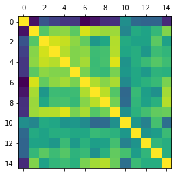

```python
## Pt 6
#Correlation Analysis
# Numerical
print(auto.corr())
# Visual
plt.matshow(auto.corr())
```

## Part 7

Combining the dummies with the auto dataset.

```python
#Combining Dummies into Auto Dataframe
auto_result = pd.concat([auto, FuelType_dummy], axis=1, sort=False)
auto_result2 = pd.concat([auto_result, DriveType_dummy], axis=1, sort=False)
print(auto_result2.head(10))
```

```
                 Name  Mileage  Capacity  Length  WheelBase  Width  \
0       Acura Integra       31      13.2     172        101     67
1            Acura TL       22      17.1     193        108     70
2       Buick Century       22      17.5     195        109     73
3       Buick LeSabre       20      17.5     200        112     74
4   Buick Park Avenue       21      18.5     207        114     75
5         Buick Regal       21      17.5     196        109     73
6  Chevrolet Cavalier       26      15.2     181        104     68
7    Chevrolet Impala       20      17.0     200        111     73
8    Chevrolet Lumina       22      16.6     201        108     73
9    Chevrolet Malibu       24      15.2     190        107     69

   TurningCircle  Weight  DoorTop  Luggage  ...   FrontLegRoom  FrontHeadRoom  \
0             39    2635     47.5     13.0  ...           41.5            2.0
1             40    3460     50.0     14.0  ...           40.5            2.5
```

[output cut: 34 more lines]

##### Fixing the incorrectly sorted regular value and removing the wrong column. Even though a warning was shown the program correclty evaluated the function.

```python
#Replacing incorrect "Regular" Value
auto_result2.Regular.loc[102] = 1
auto3 = auto_result2.drop(df.columns[19], axis=1)
```

```
/Users/homerkay/anaconda3/lib/python3.6/site-packages/pandas/core/indexing.py:189: SettingWithCopyWarning:
A value is trying to be set on a copy of a slice from a DataFrame

See the caveats in the documentation: http://pandas.pydata.org/pandas-docs/stable/indexing.html#indexing-view-versus-copy
  self._setitem_with_indexer(indexer, value)
```

```python
#Removing incorrect "Regular" Column
auto3 = auto_result2.drop(auto_result2.columns[18], axis=1)
print(auto3.head(5))
```

```
                Name  Mileage  Capacity  Length  WheelBase  Width  \
0      Acura Integra       31      13.2     172        101     67
1           Acura TL       22      17.1     193        108     70
2      Buick Century       22      17.5     195        109     73
3      Buick LeSabre       20      17.5     200        112     74
4  Buick Park Avenue       21      18.5     207        114     75

   TurningCircle  Weight  DoorTop  Luggage  FrontShoulder  FrontLegRoom  \
0             39    2635     47.5     13.0           51.5          41.5
1             40    3460     50.0     14.0           56.0          40.5
2             40    3350     50.5     17.0           58.0          44.0
3             42    3640     51.0     18.0           59.5          40.5
4             43    3880     51.0     19.0           59.5          42.5

   FrontHeadRoom  RearShoulder  RearLegRoom  RearHeadRoom  Premium  Regular  \
0            2.0          46.5         25.0           0.5        0        1
1            2.5          55.0         27.0           2.0        1        0
2            5.0          57.0         30.0           2.0        0        1
3            5.0          58.0         27.5           4.5        0        1
4            6.0          58.5         31.5           3.0        0        1

   Front  Rear
0      1     0
1      1     0
2      1     0
3      1     0
4      1     0
```

Splitting the data into 70/30 to run PCA.

```python
# Test/Train 70/30 Split
from sklearn.model_selection import train_test_split
X, y = auto3.iloc[:,1:].values, auto3.iloc[:,18].values
X_train, X_test, y_train, y_test = train_test_split(X,y,test_size=0.3,stratify=y,random_state=0)
```

Running PCA without standardization and n=3 components.

99.99% of the variance is explained with 3 components.

```python
# PCA Without standardization
pca = PCA(n_components=3)
X_train_pca = pca.fit_transform(X_train)
print('Explained Variance')
print(pca.explained_variance_)
print('Explained Variance Ratio')
print(pca.explained_variance_ratio_)
X_test_pca = pca.fit_transform(X_test)
```

```
Explained Variance
[4.69472086e+05 1.99734611e+02 9.94555492e+01]
Explained Variance Ratio
[9.99290840e-01 4.25143417e-04 2.11695268e-04]
```

Running PCA with standardization and n=3 components.

After standardization, 70.5% of the variance is explained with 3 components.

```python
# PCA With standardization
from sklearn.preprocessing import StandardScaler
sc = StandardScaler()
X_train_std = sc.fit_transform(X_train)

pca=PCA(n_components=3)
X_train_pca_std = pca.fit_transform(X_train_std)
print('Explained Variance')
print(pca.explained_variance_)
print('Explained Variance Ratio')
print(pca.explained_variance_ratio_)
```

```
Explained Variance
[9.09669119 2.56762594 1.90617211]
Explained Variance Ratio
[0.47230331 0.13331202 0.09896911]
```

## Part 8

Creating Scatter plot of weight vs mileage. Decided to choose weight as the independent variables, because I typically think of weight impacting mileage. The plot correlates well with intuition that a heavier car would get worse gas mileage.

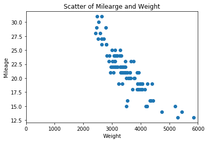

```python
## Pt 8
# Scatterplot
plt.scatter(auto3.Weight,auto3.Mileage)
# Chose Mileage as Y Value, because typically I think of that as a function of Weight
plt.title('Scatter of Milearge and Weight')
plt.xlabel("Weight")
plt.ylabel("Mileage")
plt.xlim(0, 6000)
plt.show()
```

## Part 9

Histogram of Luggage using 6 bins. The Luggage class is skewed due to the very high frequency of lower luggage values relative to middle and higher values. The MPG histogram shows the dataset to be more nomralized around the center.

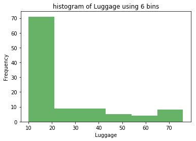

```python
## Pt 9
# Histogram
#histogram of Luggage using 6 bins
n, bins, patches = plt.hist(auto3.Luggage, 6, facecolor='green', alpha=0.6)
plt.title('histogram of Luggage using 6 bins')
plt.xlabel("Luggage")
plt.ylabel("Frequency")
plt.show()
```

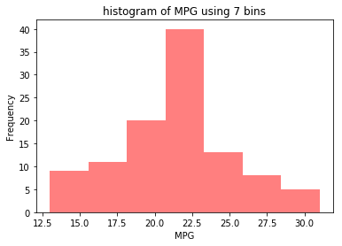

```python
#histogram of MPG using 7 bins
n, bins, patches = plt.hist(auto3.Mileage, 7, facecolor='red', alpha=0.5)
plt.title('histogram of MPG using 7 bins')
plt.xlabel("MPG")
plt.ylabel("Frequency")
plt.show()
```

## Part 10

```python
## Pt 10
# Cross Tabulation
Fuel_cross=pd.crosstab(auto3.Regular, auto3.Front,colnames=['DriveType'],rownames=['FuelType'])
print(Fuel_cross)
```

```
DriveType   0   1
FuelType
0           8  11
1          17  70
```

```
Text(0.5,1,'Fuel by Drive')
```

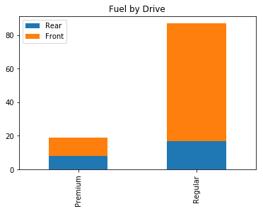

```python
#Bar plot of Fuel Type and Drive Type
Fuel_cross.columns = ['Rear','Front']
Fuel_cross.index = ['Premium','Regular']

Fuel_cross.plot(kind='bar', stacked=True)
plt.title('Fuel by Drive')
```

## Part 11

Creating a new dataframe where fuel is regular and MPG is greater than 21. Resulting in 41 rows left of the original 106.

```python
Auto_sub=auto3.query('Regular > 0.5')
Auto_sub=Auto_sub.query('Mileage > 21')
print(Auto_sub.shape)
Auto_sub.head(10)
```

```
(41, 20)
```

|  | Name | Mileage | Capacity | Length | WheelBase | Width | TurningCircle | Weight | DoorTop | Luggage | FrontShoulder | FrontLegRoom | FrontHeadRoom | RearShoulder | RearLegRoom | RearHeadRoom | Premium | Regular | Front | Rear |
| --- | --- | --- | --- | --- | --- | --- | --- | --- | --- | --- | --- | --- | --- | --- | --- | --- | --- | --- | --- | --- |
| 0 | Acura Integra | 31 | 13.2 | 172 | 101 | 67 | 39 | 2635 | 47.5 | 13.0 | 51.5 | 41.5 | 2.0 | 46.5 | 25.0 | 0.5 | 0 | 1 | 1 | 0 |
| 2 | Buick Century | 22 | 17.5 | 195 | 109 | 73 | 40 | 3350 | 50.5 | 17.0 | 58.0 | 44.0 | 5.0 | 57.0 | 30.0 | 2.0 | 0 | 1 | 1 | 0 |
| 6 | Chevrolet Cavalier | 26 | 15.2 | 181 | 104 | 68 | 38 | 2795 | 50.5 | 14.0 | 54.5 | 41.5 | 4.5 | 53.5 | 28.0 | 2.0 | 0 | 1 | 1 | 0 |
| 8 | Chevrolet Lumina | 22 | 16.6 | 201 | 108 | 73 | 44 | 3350 | 51.0 | 16.0 | 58.5 | 42.5 | 4.5 | 57.0 | 30.0 | 2.0 | 0 | 1 | 1 | 0 |
| 9 | Chevrolet Malibu | 24 | 15.2 | 190 | 107 | 69 | 40 | 3075 | 50.5 | 17.0 | 55.0 | 43.0 | 4.5 | 54.0 | 30.5 | 2.0 | 0 | 1 | 1 | 0 |
| 10 | Chevrolet Prizm | 31 | 13.2 | 175 | 97 | 67 | 34 | 2480 | 48.0 | 12.0 | 52.5 | 40.5 | 4.0 | 52.0 | 26.5 | 2.0 | 0 | 1 | 1 | 0 |
| 13 | Chrysler Cirrus | 22 | 16.0 | 186 | 108 | 72 | 39 | 3170 | 49.0 | 16.0 | 55.0 | 42.0 | 4.0 | 54.5 | 31.0 | 1.5 | 0 | 1 | 1 | 0 |
| 17 | Daewoo Lenganza | 24 | 15.8 | 184 | 105 | 70 | 41 | 3185 | 50.0 | 14.0 | 55.5 | 42.5 | 2.5 | 52.5 | 30.0 | 3.5 | 0 | 1 | 1 | 0 |
| 18 | Daewoo Nubira | 24 | 13.7 | 175 | 101 | 67 | 37 | 2815 | 50.0 | 13.0 | 53.5 | 41.0 | 4.5 | 52.5 | 27.5 | 3.0 | 0 | 1 | 1 | 0 |
| 19 | Dodge Intrepid | 22 | 17.0 | 204 | 113 | 75 | 40 | 3455 | 49.0 | 18.0 | 58.5 | 43.0 | 4.5 | 57.0 | 32.5 | 2.5 | 0 | 1 | 1 | 0 |